# Analyzing Geospatial Risk Factors in Chicago, IL

Roshini Ganesh

2023-10-20

# 1. Introduction

Policing practices in many societies have faced scrutiny for disproportionately targeting communities of color and residents of low-income neighborhoods under the assumption that they are more likely to be involved in criminal activities. This pattern of unequal policing perpetuates and exacerbates existing racial and class discrimination within society. Regrettably, these approaches often result in over-policing, which can cause more harm than good, leading to instances of unjust police brutality, disinvestment in certain neighborhoods, and disenfranchisement of low-income communities of color among other negative outcomes.

This analysis seeks to construct a model that delves into the relationship between the risk of crime in Chicago and the exposure to various risk factors that may increase an individual’s vulnerability to becoming a crime victim. While it is essential to acknowledge that battery crimes can affect individuals from all walks of life, this model specifically focuses on exploring spatial risk factors and the environmental conditions that might heighten an individual’s susceptibility to battery. By doing so, the aim is to explore and highlight the interplay of socioeconomic, geographical, and contextual elements that contribute to crime risks, and in turn, seek to promote more informed and equitable approaches to crime prevention.

This code is built upon the classwork discussed [here](https://github.com/mafichman/musa_5080_2023/tree/main).

## 1.1 R Setup and Installing Packages

This code chunk handles the essential tasks of loading necessary packages, configuring the Census API key, defining class functions, specifying a color palette, and managing global environment settings.

```r
# Loading libraries

library(tidyverse)
library(tidycensus)
library(sf)
library(RSocrata)
library(kableExtra)
library(spatstat.explore)
library(raster)
library(spdep)
library(FNN)
library(grid)
library(gridExtra)
library(knitr)
library(tidyr)
library(ggplot2)
library(viridis)
library(stringr)
library(tigris)
library(ggcorrplot)
library(stargazer)
library(classInt)

# Setting parameters for scientific notation

options(scipen=999)
options(tigris_class = "sf")

# Functions and data directory

root.dir = "https://raw.githubusercontent.com/urbanSpatial/Public-Policy-Analytics-Landing/master/DATA/"
source("https://raw.githubusercontent.com/urbanSpatial/Public-Policy-Analytics-Landing/master/functions.r")

# Invoking color palettes to be used

palettea <- c("#EA526F","#E76B74","#D7AF70","#937D64","#585B56")

paletteb <- c("#f7b267", "#f79d65", "#f4845f", "#f27059", "#f25c54")

palettec <- c("#fde725","#5ec962","#21918c","#3b528b","#440154")

paletted <- c("#ffd700","#ffb14e","#ea5f94","#9d02d7","#0000ff")

palettee <- c('#d7191c','#fdae61','#ffffbf','#abd9e9','#2c7bb6')

# Registering API Key to be used

census_api_key('bf2d507651b5a621dbadd44533fb4f3deaab26bf', overwrite = TRUE)
```

## 1.2 Read in Data from Chicago

To conduct the analysis, base data sets including police districts, police beats, and city boundaries have been pulled from the City of Chicago’s Open Data Portal. At this stage, information on various crime types is collected to understand the most prevalent and threatening crime types in Chicago city in 2017. This includes crimes such as arson, battery, domestic battery, criminal damage to property, armed robbery, retail theft, and weapons violations through possession of handgun are pulled from the open data portal. These are filtered by a specific crime type to introduce more nuance by selecting a smaller area of focus.

This uses the Socrata package for some data sets.

```r
policeDistricts <-
  st_read("https://data.cityofchicago.org/api/geospatial/fthy-xz3r?method=export&format=GeoJSON") %>%
  st_transform('ESRI:102271') %>%
  dplyr::select(District = dist_num)

policeBeats <-
  st_read("https://data.cityofchicago.org/api/geospatial/aerh-rz74?method=export&format=GeoJSON") %>%
  st_transform('ESRI:102271') %>%
  dplyr::select(District = beat_num)

bothPoliceUnits <- rbind(mutate(policeDistricts, Legend = "Police Districts"),
                         mutate(policeBeats, Legend = "Police Beats"))

battery <-
  read.socrata("https://data.cityofchicago.org/Public-Safety/Crimes-2017/d62x-nvdr") %>%
    filter(Primary.Type == "BATTERY" & (Description == "SIMPLE" | Description =="AGG PO HANDS ETC SERIOUS INJ" | Description =="PRO EMP HANDS NO/MIN INJURY" | Description =="AGGRAVATED:KNIFE/CUTTING INSTR" | Description =="AGGRAVATED: OTHER FIREARM" | Description =="AGGRAVATED: OTHER DANG WEAPON" | Description =="AGGRAVATED: HANDGUN" | Description =="AGGRAVATED PO: KNIFE/CUT INSTR" | Description =="AGGRAVATED PO: HANDGUN" | Description =="AGGRAVATED - OTHER DANGEROUS WEAPON" | Description =="AGG PRO.EMP: OTHER DANG WEAPON" | Description =="AGG PRO.EMP:KNIFE/CUTTING INST" | Description =="AGG: HANDS/FIST/FEET NO/MINOR INJURY" | Description =="AGG: HANDS/FIST/FEET SERIOUS INJURY" | Description =="AGG PRO EMP HANDS SERIOUS INJ" | Description =="AGGRAVATED OF A CHILD" | Description =="AGGRAVATED OF A SENIOR CITIZEN" )) %>%
    mutate(x = gsub("[()]", "", Location)) %>%
    separate(x,into= c("Y","X"), sep=",") %>%
    mutate(X = as.numeric(X),Y = as.numeric(Y)) %>%
    na.omit() %>%
    st_as_sf(coords = c("X", "Y"), crs = 4326, agr = "constant")%>%
    st_transform('ESRI:102271') %>%
    distinct()

chicagoBoundary <-
  st_read(file.path(root.dir,"/Chapter5/chicagoBoundary.geojson")) %>%
  st_transform('ESRI:102271')
```

## 1.3 Visualising Collected Crime Data

On examining the dataset through initial maps (not pictured), it is observed that battery crimes have the highest number of occurrences and are distributed across the city of Chicago. Therefore, it is selected as the type of crime to observe for the purpose of this analysis and prediction. In this process, domestic battery crimes are not selected because they typically occur indoors which makes it difficult to combine with common spatial risk and influence factors. The collected battery crime data is visualized as points to understand the density and distribution.

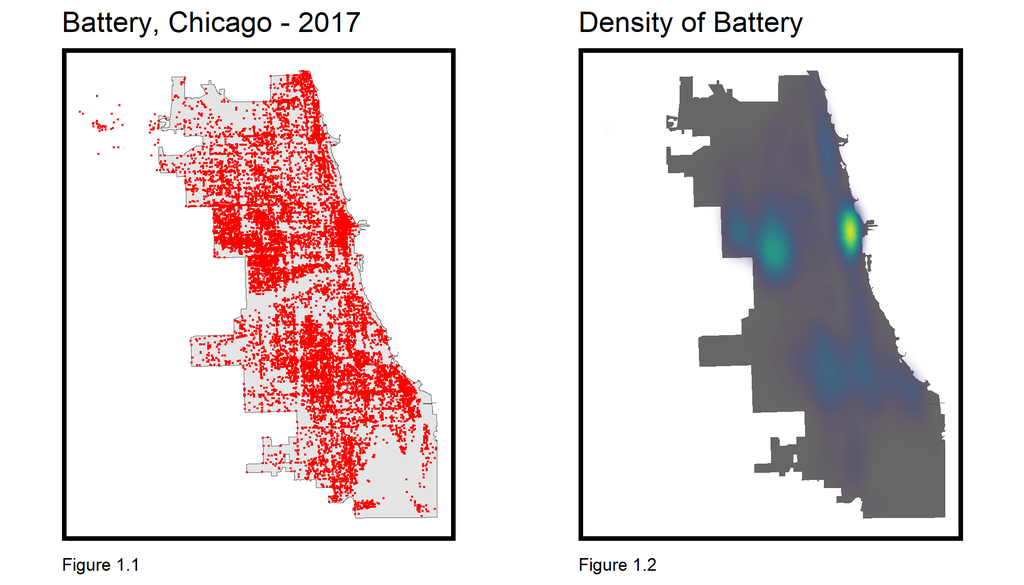

```r
# Visualising Point Data for Battery with grid.arrange to organize independent plots

grid.arrange(ncol=2,
ggplot() +
  geom_sf(data = chicagoBoundary) +
  geom_sf(data = battery, colour="red", size=0.1, show.legend = "point") +
  labs(title= "Battery, Chicago - 2017", caption = "Figure 1.1") +
  mapTheme(title_size = 14),

ggplot() +
  geom_sf(data = chicagoBoundary, fill = "grey40") +
  stat_density2d(data = data.frame(st_coordinates(battery)),
                 aes(X, Y, fill = ..level.., alpha = ..level..),
                 size = 0.01, bins = 40, geom = 'polygon') +
  scale_fill_viridis() +
  scale_alpha(range = c(0.00, 0.35), guide = FALSE) +
  labs(title = "Density of Battery", caption = "Figure 1.2") +
  mapTheme(title_size = 14) + theme(legend.position = "none"))
```

# 2. Data wrangling

## 2.1 Creating a fishnet grid

A fishnet grid is created to orient the collected data in the spatial realm. It helps provide a regular and systematic way to partition a geographic area into equally sized cells or polygons, allows for efficient data aggregation, identifies hotspots of criminal activity, and provide a clear and interpretable framework for mapping and presenting crime patterns. This approach aims to promote fairness by ensuring that each grid cell covers the same spatial extent. This prevents overrepresentation or underrepresentation of certain areas in the analysis.

```r
## Using {sf} to create the grid
## Using `.[chicagoBoundary] %>% `to clip the grid to collected data
fishnet <-
  st_make_grid(chicagoBoundary,
               cellsize = 500,
               square = TRUE) %>%
  .[chicagoBoundary] %>%
  st_sf() %>%
  mutate(uniqueID = 1:n())
```

### 2.1.1 Aggregate points to the fishnet

The prepared data is aggregated to relevant cells of the fishnet and visualised to study the nature of spatial patterns and density of distribution. The crime data is clipped to the boundaries of Chicago city.

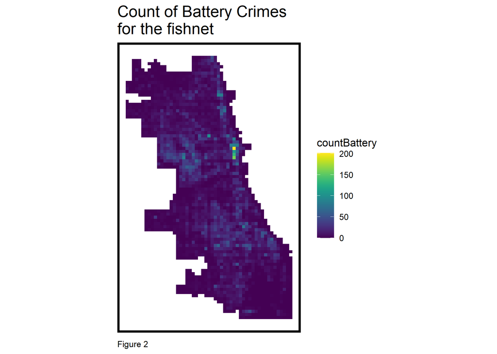

```r
# Battery Crimes Fishnet

crime_net <-
  dplyr::select(battery) %>%
  mutate(countBattery = 1) %>%
  aggregate(., fishnet, sum) %>%
  mutate(countBattery = replace_na(countBattery, 0),
         uniqueID = 1:n(),
         cvID = sample(round(nrow(fishnet) / 24),
                       size=nrow(fishnet), replace = TRUE))


# Visualizations of Crimes in Fishnet

ggplot() +
  geom_sf(data = crime_net, aes(fill = countBattery), color = NA) +
  scale_fill_viridis() +
  labs(title = "Count of Battery Crimes \nfor the fishnet", caption="Figure 2") +
  mapTheme()
```

## 2.2 Spatial Data Wrangling

A list of potential influential spatial factors including abandoned cars, abandoned buildings, graffiti, out-of-order streetlights, sanitation complaints, the presence of liquor retail stores, grocery stores, access to affordable housing, and access to transit amenities such as bikes, buses, and trains are identified as contributive or inhibitive elments to crime occurences and brought in. The data has been sourced from Chicago’s Open Data Portal.

```r
## Spatial Data Wrangling
## Risk factors

abandonCars <-
  read.socrata("https://data.cityofchicago.org/Service-Requests/311-Service-Requests-Abandoned-Vehicles/3c9v-pnva") %>%
    mutate(year = substr(creation_date,1,4)) %>% filter(year == "2017") %>%
    dplyr::select(Y = latitude, X = longitude) %>%
    na.omit() %>%
    st_as_sf(coords = c("X", "Y"), crs = 4326, agr = "constant") %>%
    st_transform(st_crs(fishnet)) %>%
    mutate(Legend = "Abandoned_Cars")

abandonBuildings <-
  read.socrata("https://data.cityofchicago.org/Service-Requests/311-Service-Requests-Vacant-and-Abandoned-Building/7nii-7srd") %>%
    mutate(year = substr(date_service_request_was_received,1,4)) %>%  filter(year == "2017") %>%
    dplyr::select(Y = latitude, X = longitude) %>%
    na.omit() %>%
    st_as_sf(coords = c("X", "Y"), crs = 4326, agr = "constant") %>%
    st_transform(st_crs(fishnet)) %>%
    mutate(Legend = "Abandoned_Buildings")

graffiti <-
  read.socrata("https://data.cityofchicago.org/Service-Requests/311-Service-Requests-Graffiti-Removal-Historical/hec5-y4x5") %>%
    mutate(year = substr(creation_date,1,4)) %>% filter(year == "2017") %>%
    filter(where_is_the_graffiti_located_ %in% c("Front", "Rear", "Side")) %>%
    dplyr::select(Y = latitude, X = longitude) %>%
    na.omit() %>%
    st_as_sf(coords = c("X", "Y"), crs = 4326, agr = "constant") %>%
    st_transform(st_crs(fishnet)) %>%
    mutate(Legend = "Graffiti")

streetLightsOut <-
  read.socrata("https://data.cityofchicago.org/Service-Requests/311-Service-Requests-Street-Lights-All-Out/zuxi-7xem") %>%
    mutate(year = substr(creation_date,1,4)) %>% filter(year == "2017") %>%
    dplyr::select(Y = latitude, X = longitude) %>%
    na.omit() %>%
    st_as_sf(coords = c("X", "Y"), crs = 4326, agr = "constant") %>%
    st_transform(st_crs(fishnet)) %>%
    mutate(Legend = "Street_Lights_Out")

sanitation <-
  read.socrata("https://data.cityofchicago.org/Service-Requests/311-Service-Requests-Sanitation-Code-Complaints-Hi/me59-5fac") %>%
    mutate(year = substr(creation_date,1,4)) %>% filter(year == "2017") %>%
    dplyr::select(Y = latitude, X = longitude) %>%
    na.omit() %>%
    st_as_sf(coords = c("X", "Y"), crs = 4326, agr = "constant") %>%
    st_transform(st_crs(fishnet)) %>%
    mutate(Legend = "Sanitation")

liquorRetail <-
  read.socrata("https://data.cityofchicago.org/resource/nrmj-3kcf.json") %>%
    filter(business_activity == "Retail Sales of Packaged Liquor") %>%
    dplyr::select(Y = latitude, X = longitude) %>%
    na.omit() %>%
    st_as_sf(coords = c("X", "Y"), crs = 4326, agr = "constant") %>%
    st_transform(st_crs(fishnet)) %>%
    mutate(Legend = "Liquor_Retail")

affordableHousing <-
    read.socrata("https://data.cityofchicago.org/resource/s6ha-ppgi.json") %>%
     dplyr::select(Y = latitude, X = longitude) %>%
     na.omit() %>%
     st_as_sf(coords = c("X", "Y"), crs = 4326, agr = "constant") %>%
     st_transform(st_crs(fishnet)) %>%
     mutate(Legend = "Affordable_Rental_Housing_Development")

## Amenities

groceryStores <-
    read.socrata("https://data.cityofchicago.org/resource/ce29-twzt.json") %>%
     dplyr::select(Y = latitude, X = longitude) %>%
     na.omit() %>%
     st_as_sf(coords = c("X", "Y"), crs = 4326, agr = "constant") %>%
     st_transform(st_crs(fishnet)) %>%
     mutate(Legend = "Grocery_Stores")

## Transit around

bikeRacks <-
    read.socrata("https://data.cityofchicago.org/resource/4ywc-hr3a.json") %>%
     dplyr::select(Y = latitude, X = longitude) %>%
     na.omit() %>%
     st_as_sf(coords = c("X", "Y"), crs = 4326, agr = "constant") %>%
     st_transform(st_crs(fishnet)) %>%
     mutate(Legend = "Bike_Racks")

ctaStations <-
    st_read("https://raw.githubusercontent.com/ChicagoCityscape/gis-data/master/stations_cta/cta_entrances.geojson") %>%
      dplyr::select(-name, -agency, -line) %>%
      na.omit() %>%
      st_transform(st_crs(fishnet)) %>%
     mutate(Legend = "CTA Stations")

metraStations <-
   st_read("https://raw.githubusercontent.com/ChicagoCityscape/gis-data/master/stations_metra/metra_entrances.geojson") %>%
     dplyr::select(-name, -agency, -line) %>%
     na.omit() %>%
     st_transform(st_crs(fishnet)) %>%
     mutate(Legend = "METRA Stations")

## Neighborhoods Data Wrangling
neighborhoods <-
  st_read("https://raw.githubusercontent.com/blackmad/neighborhoods/master/chicago.geojson") %>%
  st_transform(st_crs(fishnet))

## Vars Net
vars_net <-
  rbind(abandonCars,abandonBuildings, graffiti, streetLightsOut, sanitation, liquorRetail, affordableHousing, bikeRacks, groceryStores, ctaStations, metraStations) %>%
  st_join(., fishnet, join=st_within) %>%
  st_drop_geometry() %>%
  group_by(uniqueID, Legend) %>%
  summarize(count = n()) %>%
    full_join(fishnet) %>%
    spread(Legend, count, fill=0) %>%
    st_sf() %>%
    dplyr::select(-`<NA>`) %>%
    na.omit() %>%
    ungroup()
```

## 2.3 Feature Engineering

The nearest neighbor function is employed to establish a spatial association between incidents of battery and the risk factors we had previously extracted.

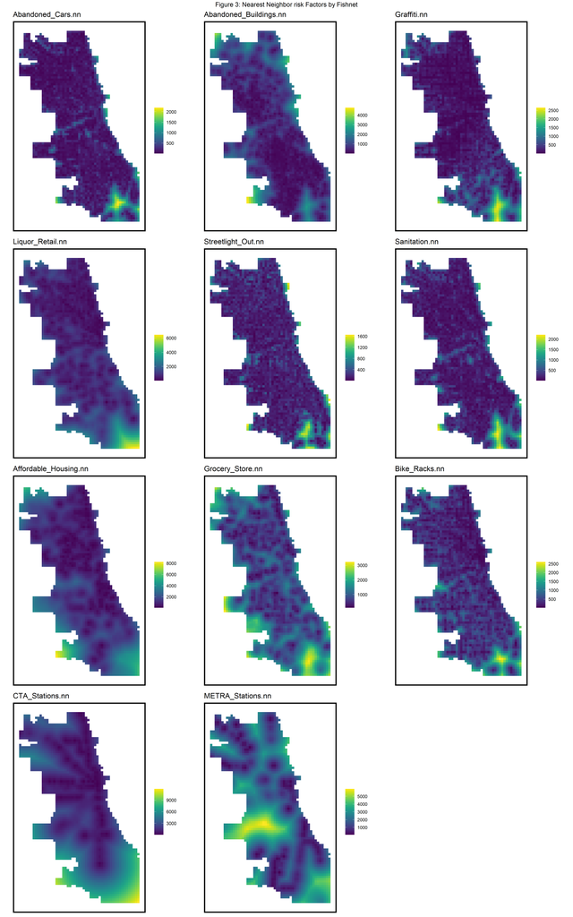

```r
st_c <- st_coordinates
st_coid <- st_centroid

vars_net <- vars_net %>%
    mutate(Abandoned_Cars.nn = nn_function(st_c(st_coid(vars_net)),
                                           st_c(abandonCars),
                                           k = 3))
vars_net <- vars_net %>%
    mutate(Abandoned_Buildings.nn = nn_function(st_c(st_coid(vars_net)),
                                           st_c(abandonBuildings),
                                           k = 3))

vars_net <- vars_net %>%
    mutate(Graffiti.nn = nn_function(st_c(st_coid(vars_net)),
                                           st_c(graffiti),
                                           k = 3))

vars_net <- vars_net %>%
    mutate(Liquor_Retail.nn = nn_function(st_c(st_coid(vars_net)),
                                           st_c(liquorRetail),
                                           k = 3))

vars_net <- vars_net %>%
    mutate(Streetlight_Out.nn = nn_function(st_c(st_coid(vars_net)),
                                           st_c(streetLightsOut),
                                           k = 3))

vars_net <- vars_net %>%
    mutate(Sanitation.nn = nn_function(st_c(st_coid(vars_net)),
                                           st_c(sanitation),
                                           k = 3))

vars_net <- vars_net %>%
    mutate(Affordable_Housing.nn = nn_function(st_c(st_coid(vars_net)),
                                           st_c(affordableHousing),
                                           k = 3))

vars_net <- vars_net %>%
    mutate(Grocery_Store.nn = nn_function(st_c(st_coid(vars_net)),
                                           st_c(groceryStores),
                                           k = 3))

vars_net <- vars_net %>%
    mutate(Bike_Racks.nn = nn_function(st_c(st_coid(vars_net)),
                                           st_c(bikeRacks),
                                           k = 3))

vars_net <- vars_net %>%
    mutate(CTA_Stations.nn = nn_function(st_c(st_coid(vars_net)),
                                           st_c(ctaStations),
                                           k = 3))

vars_net <- vars_net %>%
    mutate(METRA_Stations.nn = nn_function(st_c(st_coid(vars_net)),
                                           st_c(metraStations),
                                           k = 3))

vars_net.long.nn <-
  dplyr::select(vars_net, ends_with(".nn")) %>%
    gather(Variable, value, -geometry)

vars <- unique(vars_net.long.nn$Variable)
mapList <- list()

for(i in vars){
  mapList[[i]] <-
    ggplot() +
      geom_sf(data = filter(vars_net.long.nn, Variable == i), aes(fill=value), colour=NA) +
      scale_fill_viridis(name="") +
      labs(title=i) +
      mapTheme(title_size = 14)}

do.call(grid.arrange,c(mapList, ncol = 3, top = "Figure 3: Nearest Neighbor risk Factors by Fishnet"))
```

```r
# Join battery data to fishnet

final_net <-
  left_join(crime_net, st_drop_geometry(vars_net), by="uniqueID")

final_net <-
  st_centroid(final_net) %>%
    st_join(dplyr::select(neighborhoods, name), by = "uniqueID") %>%
    st_join(dplyr::select(policeDistricts, District), by = "uniqueID") %>%
      st_drop_geometry() %>%
      left_join(dplyr::select(final_net, geometry, uniqueID)) %>%
      st_sf() %>%
  na.omit()
```

# 3. Spatial Processes

## 3.1 Moran’s I

The Local Moran’s I function is introduced, assuming the null hypothesis that the occurrence of battery crimes at any particular location is distributed randomly in relation to its nearby neighbors. The presented data is straightforward: when we observe areas with a high count of battery crimes, we see that Moran’s I also reflects a connection to neighboring areas. In cases where a low p-value is evident, indicating statistical significance, it signifies a hotspot for battery-related incidents.

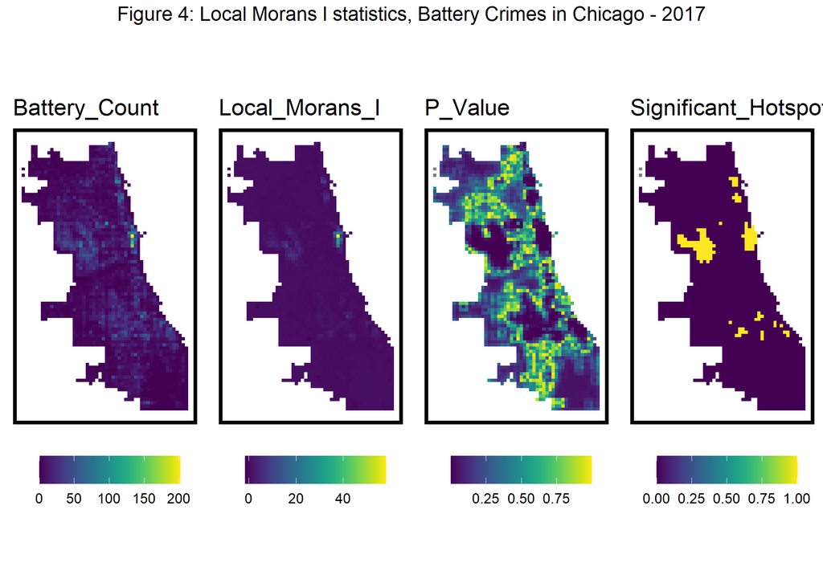

```r
#Weights
final_net.nb <- poly2nb(as_Spatial(final_net), queen=TRUE)
final_net.weights <- nb2listw(final_net.nb, style="W", zero.policy=TRUE)

##Create Local Moran
local_morans <- localmoran(final_net$countBattery, final_net.weights, zero.policy=TRUE) %>%
  as.data.frame()


#Join local Moran's I results to fishnet
final_net.localMorans <-
  cbind(local_morans, as.data.frame(final_net)) %>%
  st_sf() %>%
  dplyr::select(Battery_Count = countBattery,
                Local_Morans_I = Ii,
                P_Value = `Pr(z != E(Ii))`) %>%
  mutate(Significant_Hotspots = ifelse(P_Value <= 0.001, 1, 0)) %>%
  gather(Variable, Value, -geometry)

#Plotting
vars <- unique(final_net.localMorans$Variable)
varList <- list()

for(i in vars){
  varList[[i]] <-
    ggplot() +
      geom_sf(data = filter(final_net.localMorans, Variable == i),
              aes(fill = Value), colour=NA) +
      scale_fill_viridis(name="") +
      labs(title=i) +
      mapTheme(title_size = 14) + theme(legend.position="bottom")}

do.call(grid.arrange,c(varList, ncol = 4, top = "Figure 4: Local Morans I statistics, Battery Crimes in Chicago - 2017"))
```

## 3.2 NN Distance

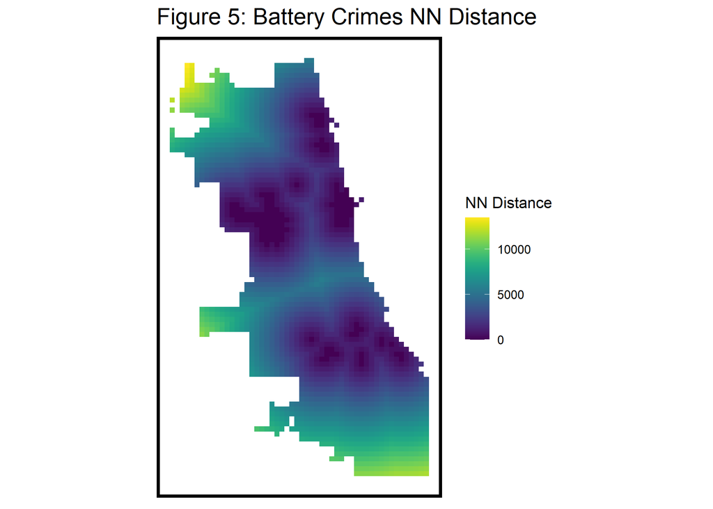

```r
#Distance to Hotspot
final_net <- final_net %>%
  mutate(battery.isSig =
           ifelse(local_morans[,5] <= 0.001, 1, 0)) %>%
  mutate(battery.isSig.dist =
           nn_function(st_c(st_coid(final_net)),
                       st_c(st_coid(filter(final_net,
                                           battery.isSig == 1))),
                       k = 1))

#Plotting NN hotspot
ggplot() +
      geom_sf(data = final_net, aes(fill=battery.isSig.dist), colour=NA) +
      scale_fill_viridis(name="NN Distance") +
      labs(title="Figure 5: Battery Crimes NN Distance") +
      mapTheme()
```

## 3.3 Correlation scatterplots

Figure 6 presents a series of small multiple scatterplots that illustrate the correlations between our spatial risk factors and the count of battery crimes, which serves as our dependent variable.

```r
# Correlation Scatterplots

correlation.long <-
  st_drop_geometry(final_net) %>%
    dplyr::select(-uniqueID, -cvID, -name, -District, -Abandoned_Buildings, -Abandoned_Cars, -Liquor_Retail, -Street_Lights_Out, -Affordable_Rental_Housing_Development, -Grocery_Stores, -Graffiti, -Bike_Racks, -Sanitation, -"CTA Stations", -"METRA Stations") %>%
    gather(Variable, Value, -countBattery) %>%
  mutate(Value = as.numeric(Value))

correlation.cor <-
  correlation.long %>%
    group_by(Variable) %>%
    summarize(correlation = cor(Value, countBattery, use = "complete.obs"))

ggplot(correlation.long, aes(Value, countBattery)) +
  geom_point(size = 0.1) +
  geom_text(data = correlation.cor, aes(label = paste("r =", round(correlation, 2))),
            x=-Inf, y=Inf, vjust = 1.5, hjust = -.1) +
  geom_smooth(method = "lm", se = FALSE, colour = "orange") +
  facet_wrap(~Variable, ncol = 2, scales = "free") +
  labs(title = "Figure 6: Battery count as a function of risk factors") +
  plotTheme()
```

[figure not shown]

## 3.4 Histogram of Dependent Variable

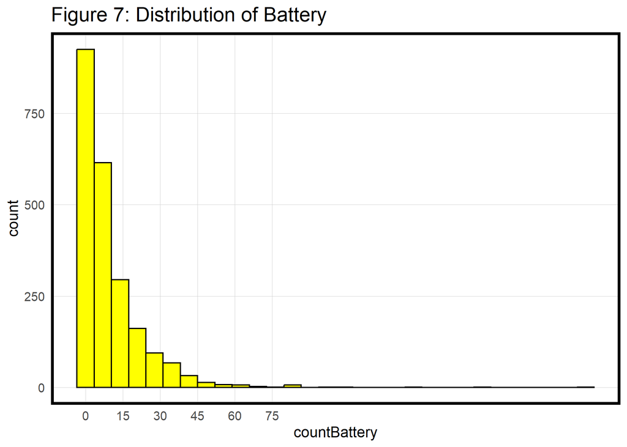

```r
#Histogram of distribution of battery

ggplot(data = final_net, aes(countBattery))+
  geom_histogram(bins = 30, color = 'black', fill = "yellow") +
  scale_x_continuous(breaks = seq(0, 80, by = 15)) +
  labs(title = 'Figure 7: Distribution of Battery') +
  plotTheme()
```

# 4. Regression and Cross Validation

## 4.1 Map of Model Errors

Two distinct cross-validation methods are used to advance the model analysis. First, K-Folds are utilized, which involves dividing the data into 100 folds, with each fold serving as a testing set. Second, the Leave-One-Group-Out (LOGO) method is applied, in which each neighborhood takes a turn as a hold-out, and the model assumes that the battery occurrences in one neighborhood are representative of another.

```r
reg.vars <- c("Abandoned_Buildings.nn", "Abandoned_Cars.nn", "Affordable_Housing.nn", "Sanitation.nn","Bike_Racks.nn", "CTA_Stations.nn", "METRA_Stations.nn","Graffiti.nn" ,"Liquor_Retail.nn", "Streetlight_Out.nn", "Grocery_Store.nn")
reg.ss.vars <- c("Abandoned_Buildings.nn", "Abandoned_Cars.nn", "Affordable_Housing.nn", "Sanitation.nn","Bike_Racks.nn", "CTA_Stations.nn", "METRA_Stations.nn","Graffiti.nn" ,"Liquor_Retail.nn", "Streetlight_Out.nn", "Grocery_Store.nn", "battery.isSig", "battery.isSig.dist")

crossValidate <- function(dataset, id, dependentVariable, indVariables) {

  allPredictions <- data.frame()
  cvID_list <- unique(dataset[[id]])

  for (i in cvID_list) {

    thisFold <- i
    cat("This hold out fold is", thisFold, "\n")

    fold.train <- filter(dataset, dataset[[id]] != thisFold) %>% as.data.frame() %>%
      dplyr::select(id, geometry, indVariables, dependentVariable)
    fold.test  <- filter(dataset, dataset[[id]] == thisFold) %>% as.data.frame() %>%
      dplyr::select(id, geometry, indVariables, dependentVariable)

    regression <-
      glm(countBattery ~ ., family = "poisson",
          data = fold.train %>%
            dplyr::select(-geometry, -id))

    thisPrediction <-
      mutate(fold.test, Prediction = predict(regression, fold.test, type = "response"))

    allPredictions <-
      rbind(allPredictions, thisPrediction)

  }
  return(st_sf(allPredictions))
}

# Cross Validation Poisson Regression
reg.cv <- crossValidate(
  dataset = final_net,
  id = "cvID",
  dependentVariable = "countBattery",
  indVariables = reg.vars) %>%
    dplyr::select(cvID = cvID, countBattery, Prediction, geometry)

reg.ss.cv <- crossValidate(
  dataset = final_net,
  id = "cvID",
  dependentVariable = "countBattery",
  indVariables = reg.ss.vars) %>%
    dplyr::select(cvID = cvID, countBattery, Prediction, geometry)

reg.spatialCV <- crossValidate(
  dataset = final_net,
  id = "name",
  dependentVariable = "countBattery",
  indVariables = reg.vars) %>%
    dplyr::select(cvID = name, countBattery, Prediction, geometry)

reg.ss.spatialCV <- crossValidate(
  dataset = final_net,
  id = "name",
  dependentVariable = "countBattery",
  indVariables = reg.ss.vars) %>%
    dplyr::select(cvID = name, countBattery, Prediction, geometry)

reg.summary <-
  rbind(
    mutate(reg.cv,           Error = Prediction - countBattery,
                             Regression = "Random k-fold CV: Just Risk Factors"),

    mutate(reg.ss.cv,        Error = Prediction - countBattery,
                             Regression = "Random k-fold CV: Spatial Process"),

    mutate(reg.spatialCV,    Error = Prediction - countBattery,
                             Regression = "Spatial LOGO-CV: Just Risk Factors"),

    mutate(reg.ss.spatialCV, Error = Prediction - countBattery,
                             Regression = "Spatial LOGO-CV: Spatial Process")) %>%
    st_sf()
```

[figure not shown]

```r
# Plotting the map
ggplot() +
  geom_sf(data = reg.summary, aes(fill = Prediction, colour = Prediction)) +
        scale_fill_viridis(option = "A") +
    scale_colour_viridis(option = "A") +
 facet_wrap(~Regression) +
      labs(title="Figure 8: Map of Model Errors", subtitle = "Random K-Fold and Spatial Cross Validation") +
  mapTheme()
```

## 4.2 Accuracy and Generalizability

The histogram and table illustrate that the introduction of the spatial process into our model leads to a reduction in errors, which may be attributed to the elimination of outliers.

```r
# Errors by LOGO-CV

error_by_reg_and_fold <-
  reg.summary %>%
    group_by(Regression, cvID) %>%
    summarize(Mean_Error = mean(Prediction - countBattery, na.rm = T),
              MAE = mean(abs(Mean_Error), na.rm = T),
              SD_MAE = mean(abs(Mean_Error), na.rm = T)) %>%
  ungroup()

error_by_reg_and_fold %>%
  arrange(desc(MAE))
error_by_reg_and_fold %>%
  arrange(MAE)
```

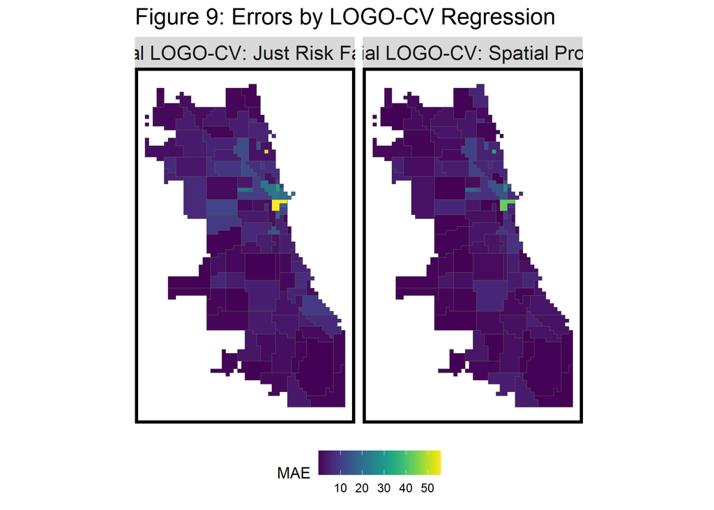

```r
#Plotting the map

error_by_reg_and_fold %>%
  filter(str_detect(Regression, "LOGO")) %>%
  ggplot() +
    geom_sf(aes(fill = MAE)) +
    facet_wrap(~Regression) +
    scale_fill_viridis() +
    labs(title = "Figure 9: Errors by LOGO-CV Regression") +
    mapTheme() + theme(legend.position="bottom")
```

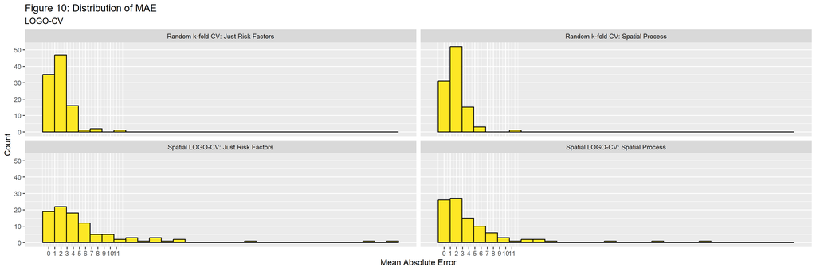

```r
# Histogram of Errors

error_by_reg_and_fold %>%
  ggplot(aes(MAE)) +
    geom_histogram(bins = 30, colour="black", fill = "#FDE725FF") +
  facet_wrap(~Regression) +
  scale_x_continuous(breaks = seq(0, 11, by = 1)) +
    labs(title="Figure 10: Distribution of MAE", subtitle = "LOGO-CV",
         x="Mean Absolute Error", y="Count")
```

```r
# Table of MAE and Standard Deviation MAE

st_drop_geometry(error_by_reg_and_fold) %>%
  group_by(Regression) %>%
    summarize(Mean_MAE = round(mean(MAE), 2),
              SD_MAE = round(sd(MAE), 2)) %>%
  kable(caption = "Figure 11: MAE and standard deviation MAE by regression") %>%
    kable_styling("striped", full_width = F) %>%
    row_spec(2, color = "black", background = "#FDE725FF") %>%
    row_spec(4, color = "black", background = "#FDE725FF")
```

Figure 11: MAE and standard deviation MAE by regression

| Regression | Mean_MAE | SD_MAE |
| --- | --- | --- |
| Random k-fold CV: Just Risk Factors | 1.88 | 1.80 |
| Random k-fold CV: Spatial Process | 1.82 | 1.58 |
| Spatial LOGO-CV: Just Risk Factors | 6.33 | 9.08 |
| Spatial LOGO-CV: Spatial Process | 4.55 | 6.67 |

```r
# Table on Moran's I on Errors by Regression

neighborhood.weights <-
  filter(error_by_reg_and_fold, Regression == "Spatial LOGO-CV: Spatial Process") %>%
    group_by(cvID) %>%
      poly2nb(as_Spatial(.), queen=TRUE) %>%
      nb2listw(., style="W", zero.policy=TRUE)

filter(error_by_reg_and_fold, str_detect(Regression, "LOGO"))  %>%
    st_drop_geometry() %>%
    group_by(Regression) %>%
    summarize(Morans_I = moran.mc(abs(Mean_Error), neighborhood.weights,
                                 nsim = 999, zero.policy = TRUE,
                                 na.action=na.omit)[[1]],
              p_value = moran.mc(abs(Mean_Error), neighborhood.weights,
                                 nsim = 999, zero.policy = TRUE,
                                 na.action=na.omit)[[3]]) %>%
  kable(caption = "Figure 12: Moran's I on Errors by Regression") %>%
    kable_styling("striped", full_width = F) %>%
    row_spec(1, color = "black", background = "#FDE725FF") %>%
    row_spec(1, color = "black", background = "#FDE725FF")
```

Figure 12: Moran’s I on Errors by Regression

| Regression | Morans_I | p_value |
| --- | --- | --- |
| Spatial LOGO-CV: Just Risk Factors | 0.2758829 | 0.001 |
| Spatial LOGO-CV: Spatial Process | 0.2045233 | 0.001 |

## 4.3 Predicted and Observed Battery Crimes

In Figure 13, we observe that our model tends to slightly overpredict battery crimes in areas with low battery crime rates, while it significantly underpredicts battery crimes in areas with high battery crime rates.

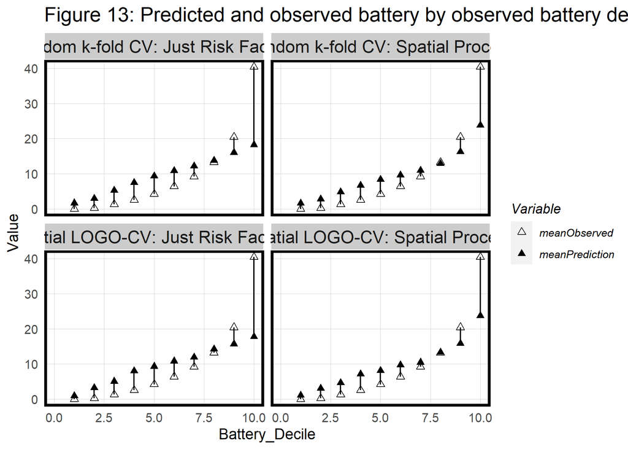

```r
#Predicted vs Observed

st_drop_geometry(reg.summary) %>%
  group_by(Regression) %>%
    mutate(Battery_Decile = ntile(countBattery, 10)) %>%
  group_by(Regression, Battery_Decile) %>%
    summarize(meanObserved = mean(countBattery, na.rm=T),
              meanPrediction = mean(Prediction, na.rm=T)) %>%
    gather(Variable, Value, -Regression, -Battery_Decile) %>%
    ggplot(aes(Battery_Decile, Value, shape = Variable)) +
      geom_point(size = 2) + geom_path(aes(group = Battery_Decile), colour = "black") +
      scale_shape_manual(values = c(2, 17)) +
      facet_wrap(~Regression) + xlim(0,10) +
      labs(title = "Figure 13: Predicted and observed battery by observed battery decile")  +
      plotTheme()
```

## 4.4 Race Context

```r
# 2018 Crimes data collection

tracts18 <-
  get_acs(geography = "tract", variables = c("B01001_001E","B01001A_001E"),
          year = 2018, state=17, county=031, geometry=T) %>%
  st_transform('ESRI:102271')  %>%
  dplyr::select(variable, estimate, GEOID) %>%
  spread(variable, estimate) %>%
  rename(TotalPop = B01001_001,
         NumberWhites = B01001A_001) %>%
  mutate(percentWhite = NumberWhites / TotalPop,
         raceContext = ifelse(percentWhite > .5, "Majority_White", "Majority_Non_White")) %>%
  .[neighborhoods,]

# Mean errors table
racialerror <- reg.summary %>%
  filter(str_detect(Regression, "LOGO")) %>%
    st_centroid() %>%
    st_join(tracts18) %>%
    na.omit() %>%
      st_drop_geometry() %>%
      group_by(Regression, raceContext) %>%
      summarize(mean.Error = mean(Error, na.rm = T)) %>%
      spread(raceContext, mean.Error) %>%
      kable(caption = "Figure 14: Mean error by neighborhood racial context") %>%
        kable_styling("striped", full_width = F)
```

```r
#Printing table

racialerror
```

Figure 14: Mean error by neighborhood racial context

| Regression | Majority_Non_White | Majority_White |
| --- | --- | --- |
| Spatial LOGO-CV: Just Risk Factors | -1.7199241 | 1.7259474 |
| Spatial LOGO-CV: Spatial Process | -0.9884735 | 0.9427917 |

## 4.5 Kernel Density

Figure 15 depicts the kernel density points of battery crimes in 2017 across different search radii.

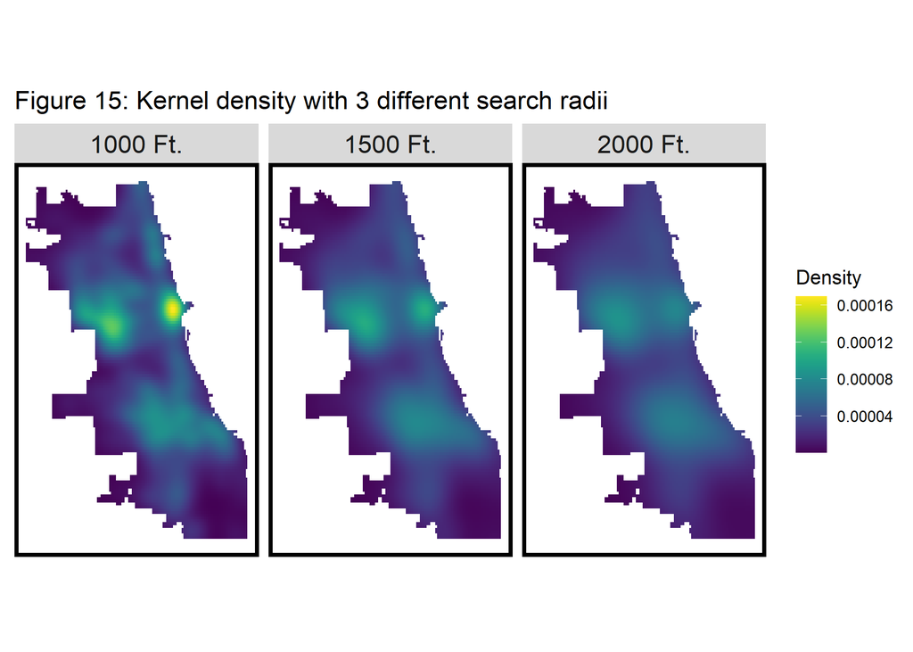

```r
battery_ppp <- as.ppp(st_coordinates(battery), W = st_bbox(final_net))
battery_KD.1000 <- spatstat.explore::density.ppp(battery_ppp, 1000)
battery_KD.1500 <- spatstat.explore::density.ppp(battery_ppp, 1500)
battery_KD.2000 <- spatstat.explore::density.ppp(battery_ppp, 2000)
battery_KD.df <- rbind(
  mutate(data.frame(rasterToPoints(mask(raster(battery_KD.1000), as(neighborhoods, 'Spatial')))), Legend = "1000 Ft."),
  mutate(data.frame(rasterToPoints(mask(raster(battery_KD.1500), as(neighborhoods, 'Spatial')))), Legend = "1500 Ft."),
  mutate(data.frame(rasterToPoints(mask(raster(battery_KD.2000), as(neighborhoods, 'Spatial')))), Legend = "2000 Ft."))

battery_KD.df$Legend <- factor(battery_KD.df$Legend, levels = c("1000 Ft.", "1500 Ft.", "2000 Ft."))

# Plotting Density
ggplot(data=battery_KD.df, aes(x=x, y=y)) +
  geom_raster(aes(fill=layer)) +
  facet_wrap(~Legend) +
  coord_sf(crs=st_crs(final_net)) +
  scale_fill_viridis(name="Density") +
  labs(title = "Figure 15: Kernel density with 3 different search radii") +
  mapTheme(title_size = 14)
```

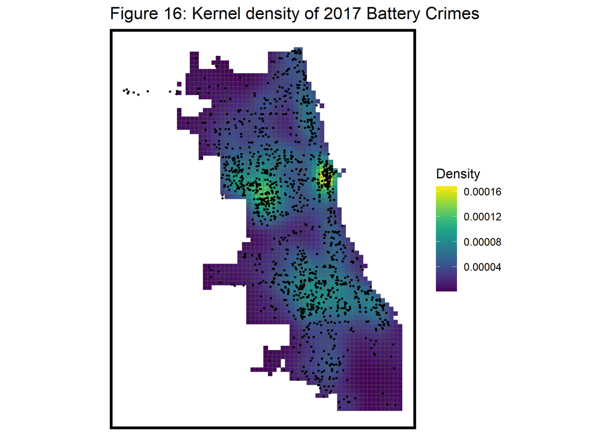

```r
# Plotting Kernel Density
as.data.frame(battery_KD.1000) %>%
  st_as_sf(coords = c("x", "y"), crs = st_crs(final_net)) %>%
  aggregate(., final_net, mean) %>%
   ggplot() +
     geom_sf(aes(fill=value)) +
     geom_sf(data = sample_n(battery, 1500), size = .5) +
     scale_fill_viridis(name = "Density") +
     labs(title = "Figure 16: Kernel density of 2017 Battery Crimes") +
     mapTheme(title_size = 14)
```

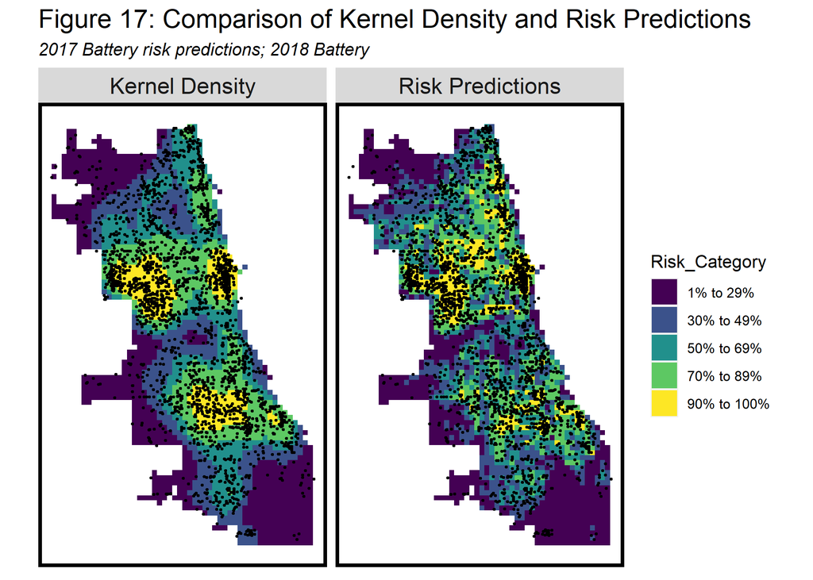

```r
# Step 1
battery18 <-
  read.socrata("https://data.cityofchicago.org/Public-Safety/Crimes-2018/3i3m-jwuy") %>%
  filter(Primary.Type == "BATTERY" &(Description == "SIMPLE" | Description =="AGG PO HANDS ETC SERIOUS INJ" | Description =="PRO EMP HANDS NO/MIN INJURY" | Description =="AGGRAVATED:KNIFE/CUTTING INSTR" | Description =="AGGRAVATED: OTHER FIREARM" | Description =="AGGRAVATED: OTHER DANG WEAPON" | Description =="AGGRAVATED: HANDGUN" | Description =="AGGRAVATED PO: KNIFE/CUT INSTR" | Description =="AGGRAVATED PO: HANDGUN" | Description =="AGGRAVATED - OTHER DANGEROUS WEAPON" | Description =="AGG PRO.EMP: OTHER DANG WEAPON" | Description =="AGG PRO.EMP:KNIFE/CUTTING INST" | Description =="AGG: HANDS/FIST/FEET NO/MINOR INJURY" | Description =="AGG: HANDS/FIST/FEET SERIOUS INJURY" | Description =="AGG PRO EMP HANDS SERIOUS INJ" | Description =="AGGRAVATED OF A CHILD" | Description =="AGGRAVATED OF A SENIOR CITIZEN" )) %>%
  mutate(x = gsub("[()]", "", Location)) %>%
  separate(x,into= c("Y","X"), sep=",") %>%
  mutate(X = as.numeric(X),
         Y = as.numeric(Y)) %>%
  na.omit %>%
  st_as_sf(coords = c("X", "Y"), crs = 4326, agr = "constant") %>%
  st_transform('ESRI:102271') %>%
  distinct() %>%
  .[fishnet,]


# Step 2
battery_KDE_sf <- as.data.frame(battery_KD.1000) %>%
  st_as_sf(coords = c("x", "y"), crs = st_crs(final_net)) %>%
  aggregate(., final_net, mean) %>%
  mutate(label = "Kernel Density",
         Risk_Category = ntile(value, 100),
         Risk_Category = case_when(
           Risk_Category >= 90 ~ "90% to 100%",
           Risk_Category >= 70 & Risk_Category <= 89 ~ "70% to 89%",
           Risk_Category >= 50 & Risk_Category <= 69 ~ "50% to 69%",
           Risk_Category >= 30 & Risk_Category <= 49 ~ "30% to 49%",
           Risk_Category >= 1 & Risk_Category  <= 29 ~ "1% to 29%")) %>%
  cbind(
    aggregate(
      dplyr::select(battery18) %>% mutate(batteryCount = 1), ., sum) %>%
    mutate(batteryCount = replace_na(batteryCount, 0))) %>%
  dplyr::select(label, Risk_Category, batteryCount)

# Step 3
battery_risk_sf <-
  filter(reg.summary, Regression == "Spatial LOGO-CV: Spatial Process") %>%
  mutate(label = "Risk Predictions",
         Risk_Category = ntile(Prediction, 100),
         Risk_Category = case_when(
           Risk_Category >= 90 ~ "90% to 100%",
           Risk_Category >= 70 & Risk_Category <= 89 ~ "70% to 89%",
           Risk_Category >= 50 & Risk_Category <= 69 ~ "50% to 69%",
           Risk_Category >= 30 & Risk_Category <= 49 ~ "30% to 49%",
           Risk_Category >= 1 & Risk_Category <= 29 ~ "1% to 29%")) %>%
  cbind(
    aggregate(
      dplyr::select(battery18) %>% mutate(batteryCount = 1), ., sum) %>%
      mutate(batteryCount = replace_na(batteryCount, 0))) %>%
  dplyr::select(label,Risk_Category, batteryCount)

# Step 4
rbind(battery_KDE_sf, battery_risk_sf) %>%
  na.omit() %>%
  gather(Variable, Value, -label, -Risk_Category, -geometry) %>%
  ggplot() +
    geom_sf(aes(fill = Risk_Category), colour = NA) +
    geom_sf(data = sample_n(battery18, 3000), size = .5, colour = "black") +
    facet_wrap(~label, ) +
    scale_fill_viridis(discrete = TRUE) +
    labs(title="Figure 17: Comparison of Kernel Density and Risk Predictions",
         subtitle="2017 Battery risk predictions; 2018 Battery") +
    mapTheme()
```

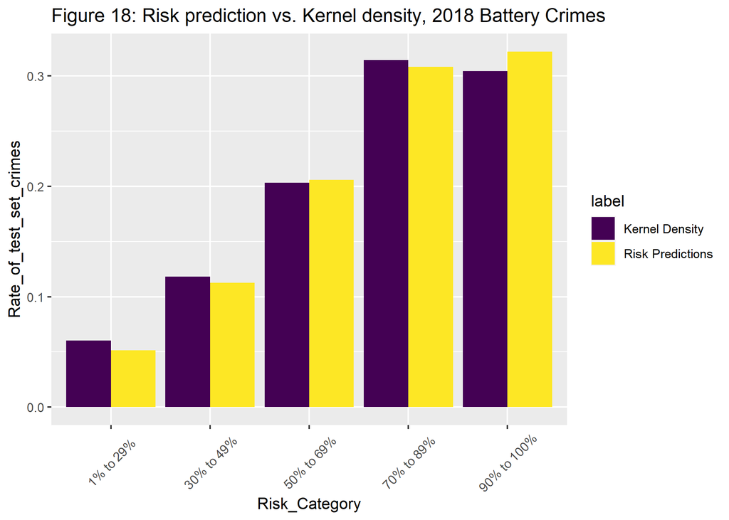

```r
# Comparing risk prediction to kernel density

rbind(battery_KDE_sf, battery_risk_sf) %>%
  st_set_geometry(NULL) %>% na.omit() %>%
  gather(Variable, Value, -label, -Risk_Category) %>%
  group_by(label, Risk_Category) %>%
  summarize(countBattery = sum(Value)) %>%
  ungroup() %>%
  group_by(label) %>%
  mutate(Rate_of_test_set_crimes = countBattery / sum(countBattery)) %>%
    ggplot(aes(Risk_Category,Rate_of_test_set_crimes)) +
      geom_bar(aes(fill=label), position="dodge", stat="identity") +
      scale_fill_viridis(discrete = TRUE) +
      labs(title = "Figure 18: Risk prediction vs. Kernel density, 2018 Battery Crimes") +
      theme(axis.text.x = element_text(angle = 45, vjust = 0.5))
```

# 5. Conclusion

One key takeaway from our model is that spatial features such as grocery stores or transit features or affordable housing rental developments are not key influential factors for battery crimes. For future applications, it may be worthwhile to explore the integration of demographic features. Additionally, our model has shed light on the presence of selection bias within the Chicago Police Department, as evidenced by our racial context analysis.

Nevertheless, I would not recommend the adoption of this model for police algorithms in predicting battery crimes in Chicago. As cities advance technologically, there is potential for the collection of more sophisticated, accurate, and comprehensive data that could significantly enhance the performance of such algorithms. It is important to recognize that while work remains to be done to refine this geospatial prediction model, there is an equal need for action on the part of police departments in Chicago and nationwide to address issues related to selection bias. Communities of color and low-income communities should no longer bear the brunt of policing or endure incidents of police brutality.